# Introduction

Algorithmic Trading is a growing field which permits to replace humans (traders) by computers. It consists of implenting trading strategies into algorithms which analyses the market and take the Buy/Hold/Sell positions by themselves. Here is the future of trading and investment decision. The reasons which pop up more frequently to back this claim are the following:

```
- It doesn't take emotion into play
- It captures a lot of information at a time and generate a faster decision
- It identifies opportunities as it catches the micro structures of financial data
```

With the development of cloud solutions, increasing in the number of brockers with low trading fees, Algorithmic Trading is quickly developping today than it was in their early stages. It moved from replicating simple strategies, based mostly on trend and related to "moving average", to more sophisticated approaches driven by Machine Learning and Deep Learning.

The development of Algorithmic trading comes also with its own challenges. Monitoring the market is not an easy task as people are leaving too much power to the computer and any bug/crach can generate a big loss. Therefore, the algorithms have to be bounded by - stop loss and - take profit parameters. In other words, managing the risk is crucial while increasing the profit is the real objective.

In this theory, algorithms (strategies) follow in general the same rule which consists of the unordered sequence of the following actions:

```
 (1) Implementing a strategy
 (2) Optimizing the strategy
 (3) Backtesting the strategy (on historical data)
 (4) Evaluating the risk
 (5) Forward testing/paper trading (on current data)
```

A valid trading strategy should be one which at least beats the Buy&Hold strategy. The other criteria for chosing a strategy over the others depend on the researcher's goal. This research is considered as a primary step in quantitative research, so forward testing is out of the scope of this paper.

In this paper, we implement, optimize, backtest and evaluate the risk of four trading strategies. These are:

```
- Gated Unit Recurrent Neural Network (a Deep Learning algorithm)
- Small Moving Average (SMA)
- Mean Reversion (MR/Bollinger)
- A combined strategy integrating the above strategies.
```

# Methodology

Our methodology is a five step process which starts with (1) constructing of the trading data from open source data, (2) Data processing (labeling and sampling process) , (3) selecting relevant features, (4) implementing the strategy, and finally (5) backtesting the strategy.

We we now move into detail for each step of our methodology.

#### (1) Data construction

```
(1.1) Open data
```

```
(1.2) Wavelet decomposition
```

It is generally known that the stock market is noisy. A standard moving average which is somehow central to all trading approaches as it encodes the market memory (e.g. volatility) is heavily influenced by noises and a high change in prices can still have impact after a long run period. The wavelet decomposition consists of decomposing the data into different frequencies. In this way, one can reconstruct the stock price by getting rid of the high frequency data. This is analogous to the Fourier transform, but it is particularly robust to non periodic data.

#### (2) Data Processing

```
(2.1) Data Labelling
```

We have analysed the historical data in other to find a labeling which generate a better profit. This consists of: -buying (+1) when the price will rise significantly afterward (in the 60 future periods), - selling (-1) when the price drops too much afterwards (in the 60 future periods) and hold (+0) when the price will fluctuate (in the 60 future periods).

This is a more intuitive labeling approach as it includes the rolling volatility of the returns and it stops losses as opposed to the usual (log/percent change) returns which only considers a step ahead or backward (lag=1) and does not have a market memory.

```
(2.2) Data sampling
```

The market in general does not follow the timely rule. For instance, practitioners does not trade at specific times, but under market circunstaces. In addition, data sampled on constant intervals either undervalues very active trading periods and overvalues low trading periods. One last reason and not the least is the bad statistical properties (low serial correlation, outliers, fail distribution normality tests) of time sampling stock data.

The resampling on either Volume or Ticks is particularly robust for machine learning algorithms as they needs more accurate data to build their own pattern recognition to generate trading signals. Note that the other strategies such as SMA and Mean Reversion/Bollinger are by nature built on paterns, so the timely sample data would be more accurate to find the average parameters for these later strategies. Our approach: To train the GRUNN model, we will resample the data over the volume. In other words, we will assume trading over volume rather than trading over time.

#### (3) Feature selection

Using the xgboost algorithm, we select features by level of importance.

#### (4) Strategy implementation

```
(4.1) The Gated Unit Recurrent Neural Network (GRUNN)
```

Which concepts are used? This is a Deep Learning algorithm from the familly of Recurrent Neural Network (RNN).

What is GRUNN architechture?

- There is an input layer composed of multiple neurons, the number of neurons is determined by the size of the feature space.
- Similarly, the number of neurons in the output layer corresponds to the output space.
- The hidden layer(s) containing memory cells cover the main functions of the GRU networks. Changes and maintenance of cell status depend on two gates in the cell: a reset gate and an update gate. Both gates are related to two elements. One comes from the input sequence, the other is the output value of memory cells from the previous time point. Accordingly, each gate fulfills different tasks in order to achieve the purpose of filtering.

Why GRUNN?

- It is expressly designed to avoid long-term dependency drawback;
- It is designed to solve the common problems of vanishing and exploding gradients in traditional RNNs when learning long-term dependencies;
- It has fewer parameters than LSTM ( Long Short Term memory ) and me train quicker or need less iteration to generalize;
- It outperformed LSTM in most task with the exception of language processing;

How does the strategy operates?

Given the above constructed stock data as input, the model considers sequences of 5 point (the prices over the 5 previous minutes in the past) and predict a probability for each class ( Buy +1, Sell -1, Hold +0 ). A position is taken by chosing the class with the highest probability.

```
(4.2) The Small Moving Average (SMA) strategy
```

Which concepts are used? This strategy consists of considering two moving average time series built on two fixed periods(one long and one short) from the financial instrument (stock data). For instance, a short moving average could be built on a fixed time equal to 50 minutes. In that case, each point of the time series is the mean of the previous 50 minutes stock prices. On the other hand, a long moving average could be built on 200 minutes.

How does the strategy operates? When the short SMA (for instance 50 minutes SMA) crossed and go over (resp. under) the long SMA ( for instance 200 minutes SMA), then we take a buy position (resp. sell position)

```
(4.3) Mean Reversion (MR)/Bollinger
```

Which concepts are used? This strategy is also plays around the moving average concept.

How does the strategy operates? This strategy considers three moving average time series viewed as a fixed width (uniform) band. The decision to sell (-1) comes when the instrument price is above the band, the decision to buy (+1) comes when the price go under the price, and finally we hold (+0) if the price stays within the band.

In a more elaborate way, this strategy needs one moving average (the center of the band), and a width to draw the two other curves, one of each side, around the first one.

```
(4.4) Combined strategy
```

Which concepts are used?

How does the strategy operates? The combined strategy is the weighted sum of the above three strategies. The coefficients of this linear combination along with the other parameters related to SMA (moving average short and long) and MR(moving average and width) are estimated using the training data in an optimization way where the goal is clearly to maximizing the profit.

#### (5) Backtesting

Backtesting is a broad concept which simply mean searching the adequate metrics to assess the viability of a strategy and also compare strategies on historical data. There are two kind of backtesting: the vectorized backtesting and the iterative backtesting. We are performing the two in this paper in a very basic way. The whole philosophie about backtesting such as time sensitivity testing is out of the scope of this paper but are rather essential to validate a model in a very professional context. In addition, we do not take into account the trading cost (as this relates heavily to the brocker fees) and this will probably downgrade strategies with huge amount of trading.

```
(5.1) Vectorized backtesting
```

We use this approach to compare the different strategies with the Buy&Hold strategy. This relies basicaly on the closing price return and consists of taking the opposite return value each time a strategy has a contrarian position with the Buy&Hold. Thus, the vectorized backtesting outputs a time series which does not have a real/true strategy return value, but which captures the volatility (risk) of our strategy. In other words, the vectorized backtesting reveals how stable is a strategy in terms of profit and also wether a strategy beats or not the Buy&Hold strategy. By transitivity, it can permit to compare two arbitrary strategies in term of their volatility.

```
(5.2) Iterative backtesting

- Equity analysis
```

We estimate the Return of Investment (ROI) of each strategy. Namely, after each trade, we report the profit/loss and we close all the positions (sell all the stocks) at the end of the observation period. This ROI is then the return (in %) when closing our position on the market;Its mathematical formulation is given by the formula:

$$ROI= \frac{Final\_Balance - Initial\_Balance}{Initial\_Balance}$$

```
- Drawdown analysis
```

We estimate the drawdown of each strategy. This is a term that indicates the amount of money lost when trading. It is calculated by finding the difference (in %) between a relative peak in equity capital and a relative depression. This measure helps to assess the empirical strategy level of risk and its efficiency in some way.

```
- Maximum drawdown
```

To make this drawdown value less sensitive to our sample and thus more robust and scalable/more informative, we have perform a Monte Carlo simulation, based on target/label shuffling, to estimate the worst case scenario. We obtain by this process the worst drawdown that the strategy could encounter.

The main indicator that measures risk is the maximum drawdown and the intrinsic risk of our strategy can be approximated with the 95th percentile of the probability distribution of the maximum drawdown (i.e. the value of the maximum drawdown that has 5% probability of being exceeded). As in this case, using an analytical approach for such a problem can be quite difficult or even impossible. That’s the point at which Monte Carlo analysis comes in help.

The complete Monte Carlo workflow for a trading strategy is then:

```
                (a) Generate a sequence of N random transactions (or simply shuffling transactions)
                (b) Measure the maximum drawdown on the sequence
                (c) Repeat the previous steps M times, obtaining M different values of the maximum drawdown.
                (d) Calculate the 95th percentile of the M obtained drawdowns
```

The assumptions we are using are that the N transactions are independent and identically distributed and that their probability distribution is stable over time.

# Summary

```python
print(Recap_data.sort_values(by="ROI (%)", ascending=False).to_markdown())
```

[output not shown]

# Comments

This quantitative research was a primary approach in investigating trading strategies. Some strategies appeared to be less risky than others, and some were more profitable than others. We believe that those which performed poorly such as SMA has to be improved. This can be done for instance by changing the optimization parameters or simply the used objective function.

On the other hand, the maximum drawback of strategies are relatively high.

In other words, a couple of improvement still need to be done before moving to the next step which is "paper trading".

# The code

## The libraries

```python
import SMABacktester as SMA
import MeanRevBacktester as MeanRev
#import TechnicalIndicators as TI
import IterativeBacktest as IBG
import Features_Selection as FS
import Stock_Trading_Data as sd
import Resample as Res
import Labeling as La
import GRUNN as gru
import imp

import datetime as dt
import pandas_datareader.data as reader

import numpy as np
import pandas as pd
import pywt

import matplotlib.pyplot as plt
plt.style.use("seaborn")
```

## The Data

- Upload the OCHL data

```python
ada=pd.read_csv("Binance_ADAUSDT_minute.csv", parse_dates=["date"],index_col="date").drop(["unix","symbol"], axis=1)
ada["spread"]=ada["close"]-ada["open"]
ada.rename(columns={"open":"Open","high":"High","low":"Low","Volume ADA": "Volume","close":"Close"},inplace=True)
ada.dropna(inplace=True)
ada.head()
```

| date | Open | High | Low | Close | Volume | Volume USDT | tradecount | spread |
| --- | --- | --- | --- | --- | --- | --- | --- | --- |
| 2021-02-28 00:07:00 | 1.30521 | 1.31190 | 1.30501 | 1.31189 | 429888.2 | 5.630007e+05 | 851 | 0.00668 |
| 2021-02-28 00:06:00 | 1.29640 | 1.30586 | 1.29640 | 1.30521 | 1003001.4 | 1.305328e+06 | 1143 | 0.00881 |
| 2021-02-28 00:05:00 | 1.28904 | 1.29780 | 1.28857 | 1.29693 | 977884.6 | 1.265504e+06 | 1221 | 0.00789 |
| 2021-02-28 00:04:00 | 1.30041 | 1.30271 | 1.28811 | 1.28952 | 2165792.5 | 2.802595e+06 | 1791 | -0.01089 |
| 2021-02-28 00:03:00 | 1.30186 | 1.30200 | 1.29534 | 1.29958 | 1209877.4 | 1.571946e+06 | 1298 | -0.00228 |

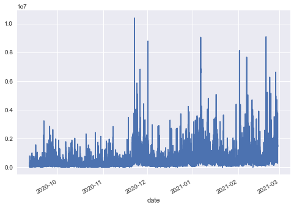

```python
ada.Volume.rolling(10).mean().plot()
```

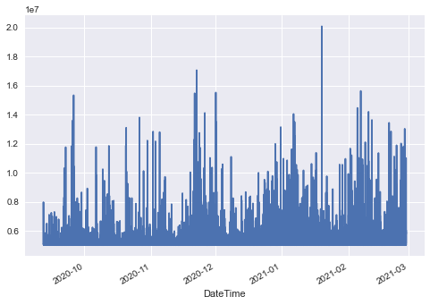

```python
#imp.reload(Res)
Res_data=Res.VolumeBarSeries(ada)
ada_grunn=Res_data.process_ticks('Close','Volume', frequency = 5000000)
ada_grunn.Volume.plot()
```

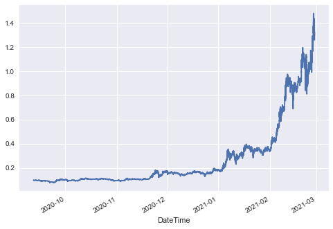

```python
ada_grunn.Close.plot()
```

- Adding technical indicators, resampling (for GRUNN model) and labelling

```python
#imp.reload(sd)
pd.options.mode.chained_assignment = None  # default='warn'

TD=sd.Trading_data_advanced("ADA-USD","2020-09-11","2021-02-28", data=ada, resample=True, denoise=0.02, frequency=5000000)

TD.build_trading_data()

TD.SMA_strategy(49, 109)

TD.MR_strategy(84,1)

TD.build_Train_test_data()

data_train_grunn=TD.train
data_val_grunn=TD.test
```

```
sizes : [6283, 1916, 5242]
rebalancing to min size : 1916 -- vs average expected : 4480.333333333333
```

- Adding technical indicators, resampling (for SMA and MR strategies) and labelling

```python
imp.reload(sd)
pd.options.mode.chained_assignment = None  # default='warn'

TD=sd.Trading_data_advanced("ADA-USD","2020-09-11","2021-02-28", data=ada, resample=False, denoise=0.02, frequency=0)

TD.build_trading_data()

TD.SMA_strategy(49, 109)

TD.MR_strategy(84,1)

TD.build_Train_test_data()

data_train=TD.train
data_val=TD.test
```

```
sizes : [77560, 34203, 75331]
rebalancing to min size : 34203 -- vs average expected : 62364.666666666664
```

- Plot the different training price data

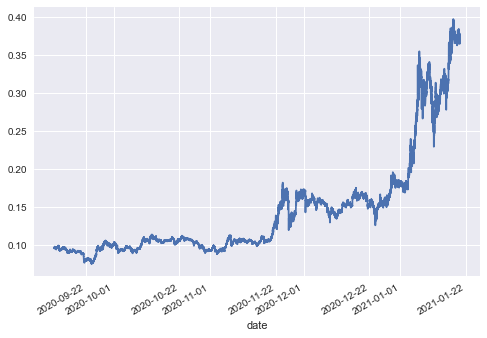

```python
data_train.price.plot()
```

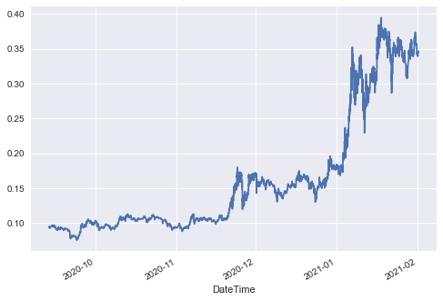

```python
data_train_grunn.price.plot()
```

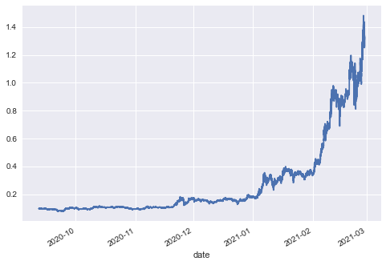

```python
ada.Close.plot()
```

## Feature selection

```python
imp.reload(FS)
feat_select=FS.feature_selection_classfication(data_train_grunn)
```

```python
feat_select.get_features(0.01)
```

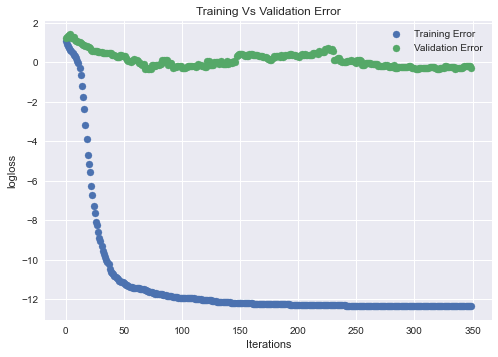

```python
feat_select.plot_learning_process()
```

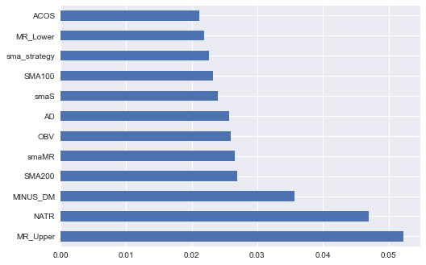

```python
feat_select.plot_important_features()
```

```python
Features=feat_select.features
```

```python
Features=Features.tolist()+['price','dir','returns','dreturns', 'Open', 'label']
print(Features)
```

```
['Low', 'Close', 'SMA7', 'SMA21', 'SMA50', 'SMA100', 'SMA200', 'TRIMA', 'WMA', 'upper', 'middle', 'CMO', 'ADX', 'TRIX', 'MINUS', 'MINUS_DM', 'PLUS_DI', 'PLUS_DM', 'PPO', 'ROC', 'fastk', 'AD', 'ADOSC', 'OBV', 'ATR', 'NATR', 'HT_DCPERIOD', 'CORREL', 'LINEARREG_INTERCEPT', 'TSF', 'ACOS', 'smaL', 'smaS'…
```

## GRUNN Strategy

- Test strategy

```python
imp.reload(gru)
```

```
<module 'GRUNN' from '/Users/miradain/Documents/Quantitative Research/Trading_Strategies/GRUNN.py'>
```

```python
tester0=gru.GRUNN_Classifier(data_train_grunn.fillna(0), Features)
```

```python
tester0.test_strategy(data_val_grunn)
```

```
++++++++++++ Fitting the GRUNN model +++++++++++

Epoch 00001: val_loss improved from inf to 1.51272, saving model to best_model.h5

Epoch 00002: val_loss improved from 1.51272 to 1.11978, saving model to best_model.h5

Epoch 00003: val_loss improved from 1.11978 to 0.92432, saving model to best_model.h5

Epoch 00004: val_loss improved from 0.92432 to 0.78399, saving model to best_model.h5

Epoch 00005: val_loss did not improve from 0.78399

Epoch 00006: val_loss improved from 0.78399 to 0.61895, saving model to best_model.h5

Epoch 00007: val_loss improved from 0.61895 to 0.57562, saving model to best_model.h5

Epoch 00008: val_loss did not improve from 0.57562

Epoch 00009: val_loss did not improve from 0.57562

Epoch 00009: ReduceLROnPlateau reducing learning rate to 0.0005000000237487257.

Epoch 00010: val_loss did not improve from 0.57562

Epoch 00011: val_loss improved from 0.57562 to 0.54987, saving model to best_model.h5

Epoch 00012: val_loss improved from 0.54987 to 0.54587, saving model to best_model.h5

Epoch 00013: val_loss did not improve from 0.54587

Epoch 00014: val_loss did not improve from 0.54587

Epoch 00014: ReduceLROnPlateau reducing learning rate to 0.0002500000118743628.

Epoch 00015: val_loss did not improve from 0.54587

Epoch 00016: val_loss improved from 0.54587 to 0.53976, saving model to best_model.h5

Epoch 00017: val_loss did not improve from 0.53976

Epoch 00018: val_loss improved from 0.53976 to 0.53268, saving model to best_model.h5

Epoch 00019: val_loss did not improve from 0.53268

Epoch 00020: val_loss did not improve from 0.53268

Epoch 00020: ReduceLROnPlateau reducing learning rate to 0.0001250000059371814.

Epoch 00021: val_loss did not improve from 0.53268

Epoch 00022: val_loss did not improve from 0.53268

Epoch 00022: ReduceLROnPlateau reducing learning rate to 6.25000029685907e-05.

Epoch 00023: val_loss did not improve from 0.53268
Epoch 00023: early stopping
++++++++++++ Computing algorithm absolute performance +++++++++++
```

```
(3.497833, 3.212678)
```

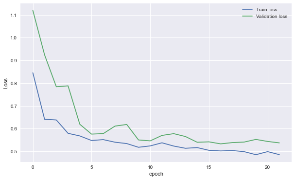

```python
tester0.plot_fitting_training()
```

```python
tester0.results.head()
```

| DateTime | Open | High | Low | Close | Volume | label | price | returns | dir | dreturns | ... | sma_strategy | smaMR | MR_Lower | MR_Upper | distance | mr_strategy | position | strategy | creturns | cstrategy |
| --- | --- | --- | --- | --- | --- | --- | --- | --- | --- | --- | --- | --- | --- | --- | --- | --- | --- | --- | --- | --- | --- |
| 2021-02-26 07:28:00 | 1.01915 | 1.02171 | 1.00916 | 1.00916 | 5160648.2 | 1 | 1.00916 | -0.001485 | -1.0 | 0.993122 | ... | -1 | NaN | NaN | NaN | NaN | 0.0 | 0 | -0.0 | 0.998516 | 1.0 |
| 2021-02-26 07:24:00 | 1.00869 | 1.00869 | 0.99880 | 1.00130 | 7016650.3 | 1 | 1.00130 | -0.007819 | -1.0 | 0.989758 | ... | -1 | NaN | NaN | NaN | NaN | 0.0 | 0 | -0.0 | 0.990739 | 1.0 |
| 2021-02-26 07:20:00 | 1.00153 | 1.00645 | 1.00090 | 1.00645 | 5999147.8 | 1 | 1.00645 | 0.005130 | 1.0 | 0.989614 | ... | -1 | NaN | NaN | NaN | NaN | 0.0 | 0 | 0.0 | 0.995834 | 1.0 |
| 2021-02-26 07:18:00 | 1.00644 | 1.00644 | 1.00383 | 1.00383 | 5079642.9 | 1 | 1.00383 | -0.002607 | -1.0 | 0.993724 | ... | -1 | NaN | NaN | NaN | NaN | 0.0 | 0 | -0.0 | 0.993242 | 1.0 |
| 2021-02-26 05:59:00 | 1.01969 | 1.02328 | 1.00634 | 1.00634 | 6078433.6 | 1 | 1.00634 | -0.015442 | -1.0 | 0.995777 | ... | -1 | NaN | NaN | NaN | NaN | 0.0 | 0 | -0.0 | 0.978023 | 1.0 |

5 rows × 151 columns

- Visualize the results

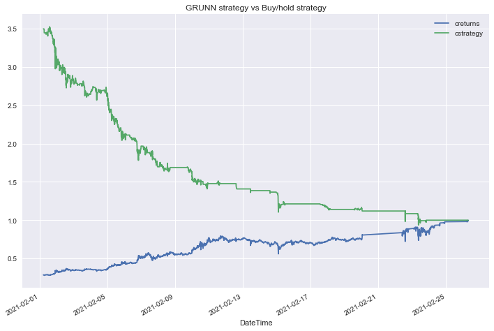

```python
tester0.Plot_results()
```

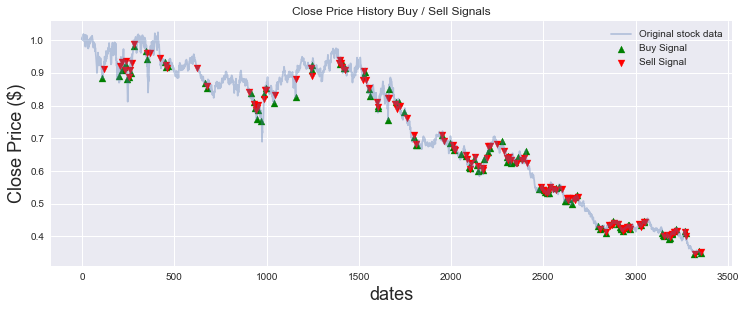

```python
tester0.plot_buy_sell('upper right')
```

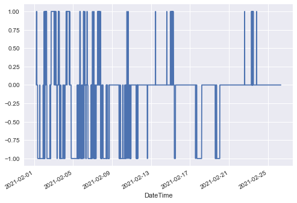

```python
tester0.results.position.plot()
```

- Volatility analysis

```python
grunn_vol=tester0.results.cstrategy.std()
Buy_Hold_vol=tester0.results.creturns.std()


print("Strategy volatility:{} | Buy-Return volatility:{}".format(grunn_vol, Buy_Hold_vol))
```

```
Strategy volatility:0.6449992649442279 | Buy-Return volatility:0.17524483623592613
```

- Equity analysis

```python
imp.reload(IBG)

backtest0=IBG.IterativeBacktest("ADA", tester0.results, 10000)
```

```python
backtest0.strategy_ROI()
```

```
---------------------------------------------------------------------------
Testing GRUNN strategy | ADA
---------------------------------------------------------------------------
2021-02-23 | Buying 11314 for 0.88
2021-02-20 | Selling 11314 for 0.94
2021-02-15 | Buying 13173 for 0.81
2021-02-12 | Selling 13173 for 0.92
2021-02-10 | Buying 15225 for 0.79
2021-02-10 | Selling 15225 for 0.82
2021-02-07 | Buying 20603 for 0.61
2021-02-07 | Selling 20603 for 0.68
2021-02-07 | Buying 22016 for 0.64
2021-02-07 | Selling 22016 for 0.63
2021-02-06 | Buying 22207 for 0.63
2021-02-06 | Selling 22207 for 0.62
2021-02-06 | Buying 25319 for 0.55
2021-02-06 | Selling 25319 for 0.54
2021-02-06 | Buying 25737 for 0.53
2021-02-06 | Selling 25737 for 0.53
2021-02-06 | Buying 25179 for 0.54
2021-02-06 | Selling 25179 for 0.54
2021-02-05 | Buying 26978 for 0.51
2021-02-05 | Selling 26978 for 0.51
2021-02-04 | Buying 32823 for 0.42
2021-02-04 | Selling 32823 for 0.43
2021-02-03 | Buying 33349 for 0.42
2021-02-03 | Selling 33349 for 0.42
2021-02-03 | Buying 32986 for 0.43
2021-02-02 | Selling 32986 for 0.43
2021-02-02 | Buying 34999 for 0.4
2021-02-02 | Selling 34999 for 0.4
2021-02-02 | Buying 33615 for 0.42
2021-02-02 | Selling 33615 for 0.41
2021-02-01 | Buying 39684 for 0.35
---------------------------------------------------------------------------
2021-02-01 | +++ CLOSING FINAL POSITION ++++
2021-02-01 | Closing position of 39684 for 0.35086
2021-02-01 | Current Balance: 13923.53
2021-02-01 | net performance (%)=39.24
2021-02-01 | number of trades executed=32
---------------------------------------------------------------------------
```

```python
backtest0.plot_drawdown()
```

[interactive chart not shown]

- Estimate the current drawdown

```python
Drawdown_grunn= round(abs(backtest0.drawdown_df()['Drawdown %']*100).max(),2 )
Drawdown_grunn
```

```
2.47
```

- Estimate the maximum drawdown

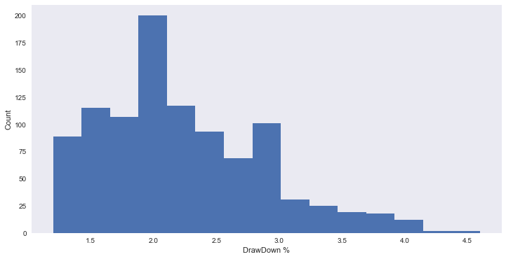

```python
backtest0.plot_worst_drawdown_distribution(1000)
```

```python
max_Drawdown_grunn=backtest0.worst_drawdown
max_Drawdown_grunn
```

```
3.5
```

## SMA Strategy

- Test strategy

```python
imp.reload(SMA)

tester1=SMA.SMABacktester(data_train,"ADA-USD", 50, 200)
tester1.test_strategy(data_val)
```

```
(0.156545, -0.104696)
```

```python
tester1.optimize_parameters((5,50,1),(80,150,1))
```

```
(array([12., 89.]), 2.376622)
```

```python
tester1=SMA.SMABacktester(data_train,"ADA-USD", 12, 89)
tester1.test_strategy(data_val)
```

```
(0.190607, -0.070633)
```

- Visualize the results

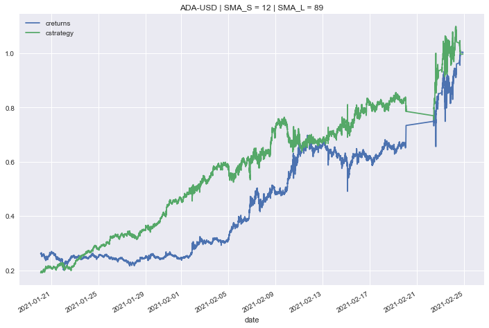

```python
tester1.plot_results()
```

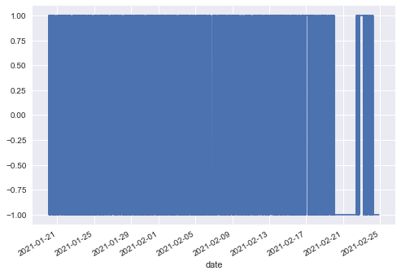

```python
tester1.results.position.plot()
```

- Volatility analysis

```python
sma_vol=tester1.results.strategy.cumsum().apply(np.exp).std()
Buy_Hold_vol=tester1.results.returns.cumsum().apply(np.exp).std()


print("Strategy volatility:{} | Buy-Return volatility:{}".format(sma_vol, Buy_Hold_vol))
```

```
Strategy volatility:0.2184582369662189 | Buy-Return volatility:0.19223272776787895
```

- ROI analysis

```python
backtest1=IBG.IterativeBacktest("ADA-USD", tester1.results, 10000)
```

```python
backtest1.strategy_ROI()
```

```
---------------------------------------------------------------------------
Testing GRUNN strategy | ADA-USD
---------------------------------------------------------------------------
2021-02-24 | Selling 0 for 1.0
2021-02-24 | Buying 9982 for 1.0
2021-02-24 | Selling 9982 for 0.98
2021-02-24 | Buying 9850 for 1.0
2021-02-24 | Selling 9850 for 0.99
2021-02-24 | Buying 9749 for 1.0
2021-02-24 | Selling 9749 for 1.0
2021-02-24 | Buying 9672 for 1.01
2021-02-24 | Selling 9672 for 1.0
2021-02-24 | Buying 10134 for 0.95
2021-02-23 | Selling 10134 for 0.94
2021-02-23 | Buying 10013 for 0.95
2021-02-23 | Selling 10013 for 0.93
2021-02-23 | Buying 9994 for 0.94
2021-02-23 | Selling 9994 for 0.94
2021-02-23 | Buying 9910 for 0.94
2021-02-23 | Selling 9910 for 0.94
2021-02-23 | Buying 10143 for 0.92
2021-02-23 | Selling 10143 for 0.95
2021-02-23 | Buying 9986 for 0.97
2021-02-23 | Selling 9986 for 0.96
2021-02-23 | Buying 9876 for 0.97
2021-02-23 | Selling 9876 for 0.95
2021-02-23 | Buying 9646 for 0.98
2021-02-23 | Selling 9646 for 0.97
2021-02-23 | Buying 9613 for 0.98
2021-02-23 | Selling 9613 for 0.97
2021-02-23 | Buying 10327 for 0.9
2021-02-23 | Selling 10327 for 0.91
2021-02-23 | Buying 10200 for 0.92
2021-02-23 | Selling 10200 for 0.91
2021-02-23 | Buying 9888 for 0.94
2021-02-23 | Selling 9888 for 0.92
2021-02-23 | Buying 9889 for 0.92
2021-02-23 | Selling 9889 for 1.01
2021-02-23 | Buying 9884 for 1.01
2021-02-23 | Selling 9884 for 1.0
```

[output cut: 831 more lines]

```
2021-01-20 | Selling 7429 for 0.36
2021-01-20 | Buying 7429 for 0.36
2021-01-20 | Selling 7429 for 0.36
2021-01-20 | Buying 7399 for 0.36
2021-01-20 | Selling 7399 for 0.36
2021-01-20 | Buying 7378 for 0.36
2021-01-20 | Selling 7378 for 0.36
2021-01-20 | Buying 7287 for 0.37
---------------------------------------------------------------------------
2021-01-20 | +++ CLOSING FINAL POSITION ++++
2021-01-20 | Closing position of 7287 for 0.36685
2021-01-20 | Current Balance: 2673.53
2021-01-20 | net performance (%)=-73.26
2021-01-20 | number of trades executed=877
---------------------------------------------------------------------------
```

```python
backtest1.plot_drawdown()
```

[interactive chart not shown]

- Estimate the current drawdown

```python
Drawdown_SMA= round(abs(backtest1.drawdown_df()['Drawdown %']*100).max() ,2)
Drawdown_SMA
```

```
133.6
```

- Estimate the maximum drawdown

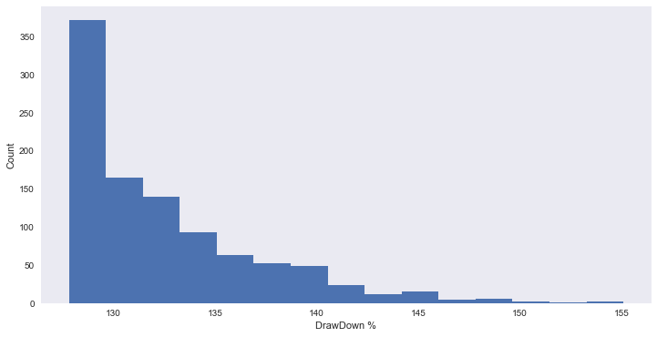

```python
backtest1.plot_worst_drawdown_distribution(1000)
```

```python
max_Drawdown_SMA=backtest1.worst_drawdown
max_Drawdown_SMA
```

```
141.505
```

## Mean Reversion Strategy (Bollinger)

- Test strategy

```python
imp.reload(MeanRev)
tester2=MeanRev.MeanRevBacktester(data_train,"ADA-USD", 75, 5)
tester2.test_strategy(data_val)
```

```
(1.032169, 0.770929)
```

```python
tester2.optimize_parameters((50,85,1),(1,10,1))
```

```
(array([77.,  1.]), 1.280932)
```

```python
tester2=MeanRev.MeanRevBacktester(data_train,"ADA-USD",77, 1)
tester2.test_strategy(data_val)
```

```
(10.795987, 10.534747)
```

- Visualize the results

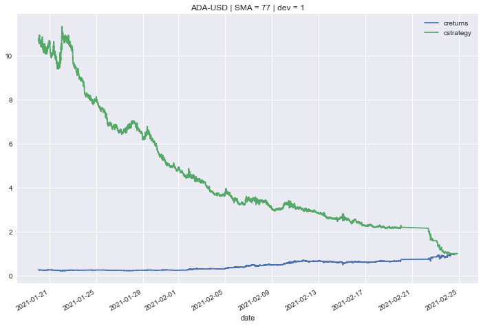

```python
tester2.plot_results()
```

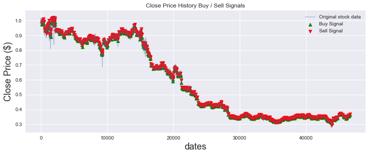

```python
tester2.plot_buy_sell()
```

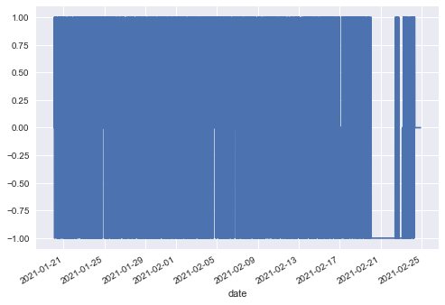

```python
tester2.results.position.plot()
```

- Volatility analysis

```python
mr_vol=tester2.results.strategy.cumsum().apply(np.exp).std()
Buy_Hold_vol=tester2.results.returns.cumsum().apply(np.exp).std()


print("Strategy volatility:{} | Buy-Return volatility:{}".format(mr_vol, Buy_Hold_vol))
```

```
Strategy volatility:2.6276774524844786 | Buy-Return volatility:0.19223272776787895
```

- ROI analysis

```python
imp.reload(IBG)
backtest2=IBG.IterativeBacktest("ADA-USD", tester2.results, 10000)
```

```python
backtest2.strategy_ROI()
```

```
---------------------------------------------------------------------------
Testing GRUNN strategy | ADA-USD
---------------------------------------------------------------------------
2021-02-24 | Buying 10060 for 0.99
2021-02-24 | Selling 10060 for 0.99
2021-02-24 | Buying 10224 for 0.97
2021-02-24 | Selling 10224 for 0.99
2021-02-24 | Buying 10293 for 0.98
2021-02-24 | Selling 10293 for 1.0
2021-02-24 | Buying 10323 for 1.0
2021-02-24 | Selling 10323 for 0.95
2021-02-23 | Buying 10451 for 0.94
2021-02-23 | Selling 10451 for 0.95
2021-02-23 | Buying 10645 for 0.93
2021-02-23 | Selling 10645 for 0.95
2021-02-23 | Buying 10832 for 0.93
2021-02-23 | Selling 10832 for 0.92
2021-02-23 | Buying 10461 for 0.95
2021-02-23 | Selling 10461 for 0.97
2021-02-23 | Buying 10634 for 0.96
2021-02-23 | Selling 10634 for 0.98
2021-02-23 | Buying 10841 for 0.96
2021-02-23 | Selling 10841 for 0.98
2021-02-23 | Buying 11177 for 0.95
2021-02-23 | Selling 11177 for 0.91
2021-02-23 | Buying 11187 for 0.91
2021-02-23 | Selling 11187 for 0.93
2021-02-23 | Buying 10589 for 0.98
2021-02-23 | Selling 10589 for 1.01
2021-02-23 | Buying 10739 for 0.99
2021-02-23 | Selling 10739 for 1.01
2021-02-22 | Buying 10930 for 0.99
2021-02-22 | Selling 10930 for 1.0
2021-02-22 | Buying 11079 for 0.99
2021-02-22 | Selling 11079 for 1.02
2021-02-22 | Buying 11619 for 0.97
2021-02-22 | Selling 11619 for 0.99
2021-02-22 | Buying 11845 for 0.97
2021-02-22 | Selling 11845 for 1.0
2021-02-22 | Buying 12061 for 0.98
```

[output cut: 686 more lines]

```
2021-01-20 | Selling 46060 for 0.35
2021-01-20 | Buying 46330 for 0.35
2021-01-20 | Selling 46330 for 0.34
2021-01-20 | Buying 46407 for 0.34
2021-01-20 | Selling 46407 for 0.35
2021-01-20 | Buying 45221 for 0.36
2021-01-20 | Selling 45221 for 0.36
2021-01-20 | Buying 44486 for 0.36
---------------------------------------------------------------------------
2021-01-20 | +++ CLOSING FINAL POSITION ++++
2021-01-20 | Closing position of 44486 for 0.36685
2021-01-20 | Current Balance: 16319.69
2021-01-20 | net performance (%)=63.2
2021-01-20 | number of trades executed=732
---------------------------------------------------------------------------
```

```python
backtest2.plot_drawdown()
```

[interactive chart not shown]

- Estimate the current drawdown

```python
Drawdown_MR= round(abs(backtest2.drawdown_df()['Drawdown %']*100).max() ,2)
Drawdown_MR
```

```
23.78
```

- Estimate the maximum drawdown

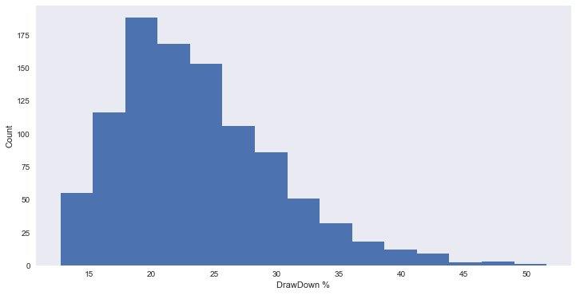

```python
backtest2.plot_worst_drawdown_distribution(1000)
```

```python
max_Drawdown_MR=backtest2.worst_drawdown
max_Drawdown_MR
```

```
35.1
```

## Combined strategy

- Optimizing function

```python
tester00=gru.GRUNN_Classifier(data_train.fillna(0), Features)
tester00.test_strategy(data_train.fillna(0))
```

```
++++++++++++ Fitting the GRUNN model +++++++++++

Epoch 00001: val_loss improved from inf to 1.68364, saving model to best_model.h5

Epoch 00002: val_loss improved from 1.68364 to 1.24041, saving model to best_model.h5

Epoch 00003: val_loss improved from 1.24041 to 1.09259, saving model to best_model.h5

Epoch 00004: val_loss improved from 1.09259 to 1.05373, saving model to best_model.h5

Epoch 00005: val_loss improved from 1.05373 to 0.92663, saving model to best_model.h5

Epoch 00006: val_loss improved from 0.92663 to 0.78235, saving model to best_model.h5

Epoch 00007: val_loss improved from 0.78235 to 0.72913, saving model to best_model.h5

Epoch 00008: val_loss did not improve from 0.72913

Epoch 00009: val_loss improved from 0.72913 to 0.69356, saving model to best_model.h5

Epoch 00010: val_loss did not improve from 0.69356

Epoch 00011: val_loss improved from 0.69356 to 0.56887, saving model to best_model.h5

Epoch 00012: val_loss did not improve from 0.56887

Epoch 00013: val_loss did not improve from 0.56887

Epoch 00013: ReduceLROnPlateau reducing learning rate to 0.0005000000237487257.

Epoch 00014: val_loss improved from 0.56887 to 0.51046, saving model to best_model.h5

Epoch 00015: val_loss did not improve from 0.51046

Epoch 00016: val_loss did not improve from 0.51046

Epoch 00016: ReduceLROnPlateau reducing learning rate to 0.0002500000118743628.

Epoch 00017: val_loss improved from 0.51046 to 0.50600, saving model to best_model.h5

Epoch 00018: val_loss did not improve from 0.50600

Epoch 00019: val_loss improved from 0.50600 to 0.47749, saving model to best_model.h5

Epoch 00020: val_loss improved from 0.47749 to 0.47643, saving model to best_model.h5

Epoch 00021: val_loss did not improve from 0.47643

Epoch 00022: val_loss did not improve from 0.47643

Epoch 00022: ReduceLROnPlateau reducing learning rate to 0.0001250000059371814.

Epoch 00023: val_loss did not improve from 0.47643

Epoch 00024: val_loss did not improve from 0.47643

Epoch 00024: ReduceLROnPlateau reducing learning rate to 6.25000029685907e-05.

Epoch 00025: val_loss did not improve from 0.47643
Epoch 00025: early stopping
++++++++++++ Computing algorithm absolute performance +++++++++++
```

```
(6.527511, 6.10501)
```

```python
def optimal_strategy(parameters):

    # GRUNN
    #tester=gru.GRUNN_Classifier(data.fillna(0), Features)
    #tester.test_strategy(data)

    # SMA
    tester1=SMA.SMABacktester(data_train.fillna(0),"ADA-USD", int(parameters[0]), int(parameters[1]))
    tester1.test_strategy(data_train.fillna(0))

    # Bollinger
    tester2=MeanRev.MeanRevBacktester(data_train.fillna(0),"ADA-USD", int(parameters[2]), int(parameters[3]))
    tester2.test_strategy(data_train.fillna(0))

    # Create comb
    comb=tester1.results.loc[:,["returns","position"]].copy()
    comb.rename(columns={"position":"position_SMA"}, inplace=True)
    comb["position_MR"]=tester2.results.position

    position_GRUNN=tester00.results.position
    comb=comb.drop(comb.index[[0,1,2,3,4]])
    #comb["position_GRUNN"]=tester.results.position


    # Methods
    comb["position_comb"]=np.sign(comb.position_SMA*parameters[4] + comb.position_MR*parameters[5] + position_GRUNN*parameters[6])

    # Backtest (Vectorized Backtesting)
    comb["strategy"]=comb["position_comb"].shift(1)*comb["returns"]
    comb.dropna(inplace=True)
    comb["creturns"]=comb.returns.cumsum().apply(np.exp)
    comb["cstrategy"]=comb.strategy.cumsum().apply(np.exp)

    return -comb["cstrategy"].iloc[-1] # negative absolute performance to be minimize
```

```python
optimal_strategy((20,150,60,1,1,1,1))
```

```
-2.8534685409549985
```

- Optimal Strategy parameters

```python
from scipy.optimize import minimize
bnds=((5,50),(80,150),(50,85),(1,10),(0,1),(0,1),(0,1))
start_par=(6,85,60,2,1,1,1)
opts=minimize(optimal_strategy, start_par, method="Powell", bounds=bnds)
opts.x
```

```
array([11.83462968, 89.73222839, 83.92123519,  6.24923278,  0.99992812,
        0.99989304,  0.99993389])
```

```python
# These are the optimal parameters
opt_par=(11,89,83,6, 0.99992812, 0.99989304, 0.99993389)
-optimal_strategy(opt_par)
```

```
10.182849217559287
```

#### Combined strategy plot vs Buy/hold strategy

- data

```python
tester01=gru.GRUNN_Classifier(data_train.fillna(0), Features)
tester01.test_strategy(data_val.fillna(0))
```

```
++++++++++++ Fitting the GRUNN model +++++++++++

Epoch 00001: val_loss improved from inf to 1.37419, saving model to best_model.h5

Epoch 00002: val_loss improved from 1.37419 to 0.97501, saving model to best_model.h5

Epoch 00003: val_loss did not improve from 0.97501

Epoch 00004: val_loss did not improve from 0.97501

Epoch 00004: ReduceLROnPlateau reducing learning rate to 0.0005000000237487257.

Epoch 00005: val_loss improved from 0.97501 to 0.59479, saving model to best_model.h5

Epoch 00006: val_loss improved from 0.59479 to 0.57604, saving model to best_model.h5

Epoch 00007: val_loss improved from 0.57604 to 0.55590, saving model to best_model.h5

Epoch 00008: val_loss did not improve from 0.55590

Epoch 00009: val_loss did not improve from 0.55590

Epoch 00009: ReduceLROnPlateau reducing learning rate to 0.0002500000118743628.

Epoch 00010: val_loss improved from 0.55590 to 0.52203, saving model to best_model.h5

Epoch 00011: val_loss improved from 0.52203 to 0.48147, saving model to best_model.h5

Epoch 00012: val_loss did not improve from 0.48147

Epoch 00013: val_loss did not improve from 0.48147

Epoch 00013: ReduceLROnPlateau reducing learning rate to 0.0001250000059371814.

Epoch 00014: val_loss did not improve from 0.48147

Epoch 00015: val_loss did not improve from 0.48147

Epoch 00015: ReduceLROnPlateau reducing learning rate to 6.25000029685907e-05.

Epoch 00016: val_loss did not improve from 0.48147
Epoch 00016: early stopping
++++++++++++ Computing algorithm absolute performance +++++++++++
```

```
(32.821855, 32.575736)
```

```python
def optimal_strategy_data(parameters):
    # SMA
    tester1=SMA.SMABacktester(data_train.fillna(0),"ADA-USD", int(parameters[0]), int(parameters[1]))
    tester1.test_strategy(data_val.fillna(0))

    # Bollinger
    tester2=MeanRev.MeanRevBacktester(data_train.fillna(0),"ADA-USD", int(parameters[2]), int(parameters[3]))
    tester2.test_strategy(data_val.fillna(0))

    # Create comb
    comb=tester1.results.loc[:,["returns","position"]].copy()
    comb.rename(columns={"position":"position_SMA"}, inplace=True)
    comb["position_MR"]=tester2.results.position

    position_GRUNN=tester01.results.position
    comb=comb.drop(comb.index[[0,1,2,3,4]])

    # Methods
    comb["position_comb"]=np.sign(comb.position_SMA*parameters[4] + comb.position_MR*parameters[5] + position_GRUNN*parameters[6])

    # Backtest (Vectorized Backtesting)
    comb["strategy"]=comb["position_comb"].shift(1)*comb["returns"]
    comb.dropna(inplace=True)
    comb["creturns"]=comb.returns.cumsum().apply(np.exp)
    comb["cstrategy"]=comb.strategy.cumsum().apply(np.exp)

    return comb
```

```python
comb=optimal_strategy_data(opt_par)
```

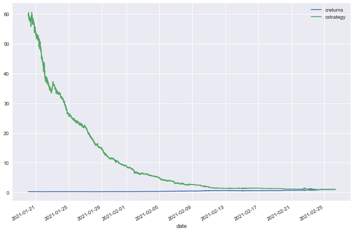

```python
comb[["creturns","cstrategy"]].plot(figsize=(12,8))
plt.show()
```

- Volatility analysis

```python
comb_vol=comb.strategy.cumsum().apply(np.exp).std()
Buy_Hold_vol=comb.returns.cumsum().apply(np.exp).std()


print("Strategy volatility:{} | Buy-Return volatility:{}".format(comb_vol, Buy_Hold_vol))
```

```
Strategy volatility:14.544276510294148 | Buy-Return volatility:0.1814928795214658
```

- Equity analysis

```python
comb.rename(columns={"position_comb":"position"}, inplace=True)
comb["price"]=data_val.price
backtest3=IBG.IterativeBacktest("ADA_USD", comb, 10000)
```

```python
backtest3.strategy_ROI()
```

```
---------------------------------------------------------------------------
Testing GRUNN strategy | ADA_USD
---------------------------------------------------------------------------
2021-02-26 | Selling 0 for 1.01
2021-02-24 | Buying 9951 for 1.0
2021-02-24 | Selling 9951 for 1.0
2021-02-24 | Buying 9810 for 1.01
2021-02-24 | Selling 9810 for 1.0
2021-02-24 | Buying 9626 for 1.01
2021-02-24 | Selling 9626 for 0.99
2021-02-24 | Buying 9447 for 1.01
2021-02-24 | Selling 9447 for 1.01
2021-02-24 | Buying 9497 for 1.01
2021-02-24 | Selling 9497 for 1.0
2021-02-24 | Buying 9459 for 1.0
2021-02-24 | Selling 9459 for 1.0
2021-02-24 | Buying 9463 for 1.0
2021-02-24 | Selling 9463 for 0.99
2021-02-24 | Buying 9359 for 1.0
2021-02-24 | Selling 9359 for 0.99
2021-02-24 | Buying 9265 for 1.0
2021-02-24 | Selling 9265 for 1.01
2021-02-24 | Buying 9249 for 1.01
2021-02-24 | Selling 9249 for 1.01
2021-02-24 | Buying 9278 for 1.01
2021-02-24 | Selling 9278 for 1.01
2021-02-24 | Buying 9334 for 1.0
2021-02-24 | Selling 9334 for 1.01
2021-02-24 | Buying 9343 for 1.0
2021-02-24 | Selling 9343 for 1.0
2021-02-24 | Buying 9333 for 1.0
2021-02-24 | Selling 9333 for 1.0
2021-02-24 | Buying 9243 for 1.01
2021-02-24 | Selling 9243 for 1.0
2021-02-24 | Buying 9744 for 0.94
2021-02-24 | Selling 9744 for 0.95
2021-02-23 | Buying 9844 for 0.95
2021-02-23 | Selling 9844 for 0.95
2021-02-23 | Buying 9903 for 0.94
2021-02-23 | Selling 9903 for 0.95
```

[output cut: 2521 more lines]

```
2021-01-20 | Selling 122708 for 0.36
2021-01-20 | Buying 122544 for 0.36
2021-01-20 | Selling 122544 for 0.37
2021-01-20 | Buying 121607 for 0.37
2021-01-20 | Selling 121607 for 0.37
2021-01-20 | Buying 121858 for 0.37
2021-01-20 | Selling 121858 for 0.37
2021-01-20 | Buying 121571 for 0.37
---------------------------------------------------------------------------
2021-01-20 | +++ CLOSING FINAL POSITION ++++
2021-01-20 | Closing position of 121571 for 0.36685
2021-01-20 | Current Balance: 44598.51
2021-01-20 | net performance (%)=345.99
2021-01-20 | number of trades executed=2567
---------------------------------------------------------------------------
```

```python
backtest3.plot_drawdown()
```

[interactive chart not shown]

- Estimate the current drawdown

```python
Drawdown_comb= round(abs(backtest3.drawdown_df()['Drawdown %']*100).max() ,2)
Drawdown_comb
```

```
7.69
```

- Estimate the maximum drawdown

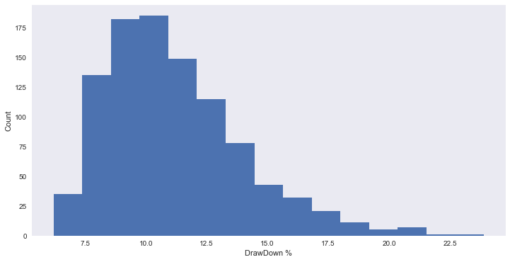

```python
backtest3.plot_worst_drawdown_distribution(1000)
```

```python
max_Drawdown_comb=backtest2.worst_drawdown
max_Drawdown_comb
```

[output not shown]

## Buy/Hold strategy

- ROI analysis

```python
initial_balance=10000
initial_unit=int(initial_balance/data_val.price[0])
current_balance=initial_unit*data_val.price[-1]
ROI_Buy_Hold=((current_balance-initial_balance)/initial_balance)*100
ROI_Buy_Hold
```

```
-63.689187000000004
```

## Summary

```python
Recap_data=pd.DataFrame({}, columns=["Strategy","ROI (%)", "Risk","Drawdown (%)","Max Drawdown (%)","Trades"])
```

```python
Recap_data["Strategy"]=np.array(["Buy/Hold","GRUNN", "SMA", "Mean Reversion","Combined"])
Recap_data["Risk"]=np.array([Buy_Hold_vol, grunn_vol, sma_vol, mr_vol, comb_vol])
Recap_data["Trades"]=np.array([0, backtest0.trades, backtest1.trades, backtest2.trades, backtest3.trades])
Recap_data["ROI (%)"]=np.array([ROI_Buy_Hold, backtest0.ROI, backtest1.ROI, backtest2.ROI, backtest3.ROI])
Recap_data["Drawdown (%)"]=np.array(["NA", Drawdown_grunn, Drawdown_SMA, Drawdown_MR,Drawdown_comb ])
Recap_data["Max Drawdown (%)"]=np.array(["NA", max_Drawdown_grunn, max_Drawdown_SMA, max_Drawdown_MR,max_Drawdown_comb ])
```

```python
print(Recap_data.sort_values(by="ROI (%)", ascending=False).to_markdown())
```

[output not shown]

## Comments

This quantitative research was a primary approach in investigating trading strategies. Some strategies appeared to be less risky than others, and some were more profitable than others. We believe that those which performed poorly such as SMA has to be improved. This can be done for instance by changing the optimization parameters or simply the used objective function.

On the other hand, the maximum drawback of strategies are relatively high.

In other words, a couple of improvement need to be done before moving to the next step which is "paper trading".